# Homework 13

Modified

We 2023-09-13 16:49

Due

Fr 2025-10-31 8:00

Do the following in engineering format.

1. The spectral distribution of the radiation emitted by a diffuse surface may be approximated as follows.

   Figure 1: Spectral Distribtion

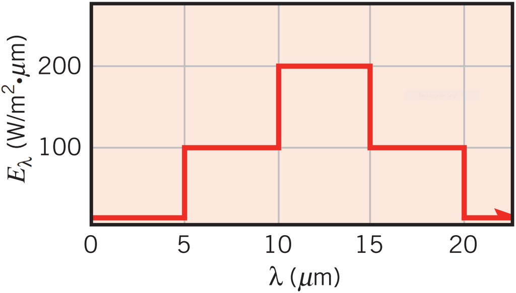

   1. What is the total emissive power?

      *Answer:* $2000 \frac{W}{m^2}$
   2. What is the total intensity of the radiation emitted in the normal direction and at an angle of 30 from the normal?

      *Answer:* $637 \frac{W}{m^2 sr}$
   3. Determine the fraction of the emissive power leaving the surface in the directions $\frac{\pi}{4} \geq \theta \geq \frac{\pi}{2}$.

      *Answer:* $0.5$
2. Consider an opaque horizontal plate that is well insulated on its back side. The irradiation on the plate is $2500 \frac{W}{m^2}$, of which $500 \frac{W}{m^2}$ is reflected. The plate is at $227 ^\circ C$ and has an emissive power of $1200\frac{W}{m^2}$. Air at $127 ^\circ C$ flows over the plate with a heat transfer convection coefficient of $15 \frac{W}{m^2}K$. Determine the emissivity, absorptivity, and radiosity of the plate. What is the net heat transfer rate per unit area?

   *Answers:* $0.34$, $0.8$, $1700 \frac{W}{m^2}$, and $-700 \frac{W}{m^2}$
3. A horizontal semitransparent plate is uniformly irradiated from above and below, while air at $T_\infty=310 K$ flows over the top and bottom surfaces, providing a uniform convection heat transfer coefficient of $h = 50 \frac{W}{m^2K}$. The absorptivity of the plate to the irradiation is $0.40$. Under steady-state conditions measurements made with a radiation detector above the top surface indicate a radiosity (which includes transmission, as well as reflection and emission) of $J = 5500 \frac{W}{m^2}$, while the plate is at a uniform temperature of $T = 360 K$. Determine the irradiation G and the emissivity of the plate. Is the plate gray $\left( \varepsilon = \alpha \right)$ for the prescribed conditions?

   *Answers:* $8000 \frac{W}{m^2}$, and $0.74$
4. The energy flux associated with solar radiation incident on the outer surface of the earth’s atmosphere has been accurately measured and is known to be $1368 \frac{W}{m^2}$. The diameters of the sun and earth are $1.39 \times 10^9$ and $1.27 \times 10^7 m$, respectively, and the distance between the sun and the earth is $1.5 \times 10^{11} m$.
   1. What is the emissive power of the sun?

      *Answer:* $6.37 \times 10^7 \frac{W}{m^2}$
   2. Approximateing the sun’s surface as black, what is its temperature?

      *Answer:* $5790 K$
   3. At what wavelength is the spectral emissive power of the sun a maximum?

      *Answer:* $0.5 \mu m$
   4. Assuming the earth’s surface to be black and the sun to be the only source of energy for the earth, estimate the earth’s surface temperature.

      *Answer:* $279 K$

Homework submission should be made on [Canvas](https://canvas.latech.edu).